```python
import numpy as np

import matplotlib.pyplot as plt
plt.rcParams['axes.labelsize'] = 16
plt.rcParams['axes.labelweight'] = 'bold'
plt.rcParams['axes.titlesize'] = 25
plt.rcParams['axes.titleweight'] = 'bold'
plt.rcParams['xtick.labelsize']=16
plt.rcParams['ytick.labelsize']=16

from scipy.optimize import curve_fit

import pandas as pd
pd.set_option("display.precision", 2)
from IPython.display import display
from IPython.display import display_html
from itertools import chain,cycle
```

# Aufgabe 1

Zunächst zeigen wir eine gute, eine mittlere und eine schlechtere Registrierung:

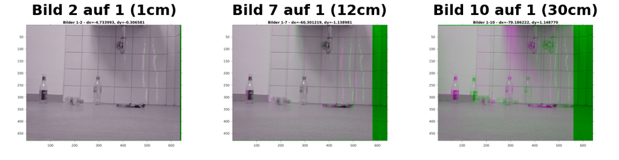

```python
imgs = [plt.imread(f'aufgabe1/Bilder/Bilder_1_{i}.png') for i in [2, 7, 10]]
titles = ['Bild 2 auf 1 (1cm)', 'Bild 7 auf 1 (12cm)', 'Bild 10 auf 1 (30cm)']
fig, axs = plt.subplots(1,3, sharex=True, sharey=True, figsize=(15,10), tight_layout=True)
for ax, img, t in zip(axs, imgs, titles):
    ax.imshow(img)
    ax.axis('off')
    ax.set_title(t)
```

Als nächstes Bestimmen wir das Verhältnis von Pixel und cm:

```python
img1, img2, dist, dx, dy, MI, MSD = np.loadtxt('aufgabe1/aufgabe1_parameter.txt', skiprows=1).T

idx = np.argsort(dist)
dist = dist[idx]
dx = dx[idx]
MI = MI[idx]
MSD = MSD[idx]
```

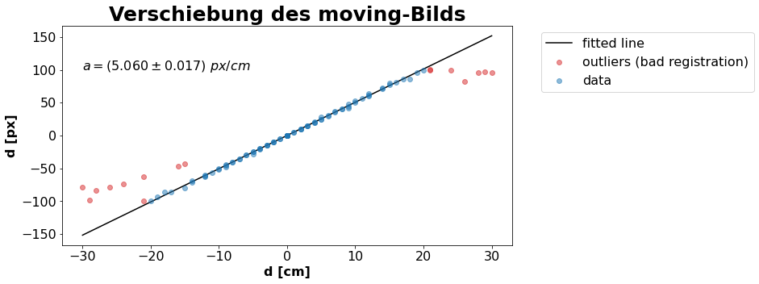

```python
data = np.stack((dist, dx)).T
good = np.concatenate((data[7:11], data[13:-7]))
bad = np.concatenate((data[:7], data[11:13],data[-7:]))

def line(x,a,b):
    return x*a+b

popt, pcov = curve_fit(line, good.T[0], good.T[1])

a = popt[0]
a_err = pcov[0][0]**0.5

plt.figure(figsize=(10,5))
plt.title('Verschiebung des moving-Bilds')
plt.xlabel('d [cm]')
plt.ylabel('d [px]')
plt.scatter(bad.T[0], bad.T[1], alpha=0.5, color ='tab:red', label='outliers (bad registration)')
plt.scatter(good.T[0], good.T[1], alpha=0.5, color ='tab:blue', label='data')
plt.plot(data.T[0], line(data.T[0], *popt), color='k', zorder=-1, label='fitted line')
plt.text(-30,100, '$a = ({:.3f} \pm {:.3f})\ px/cm$'.format(a, a_err), size=16)
plt.legend(bbox_to_anchor=(1.05, 1), fontsize='16')
plt.show()
```

Resultat des Fits: $$a = (5.060 \pm 0.017) \frac{px}{cm}$$

Als letzten Teil von Aufgabe 1 werden noch die Metriken geplotted.

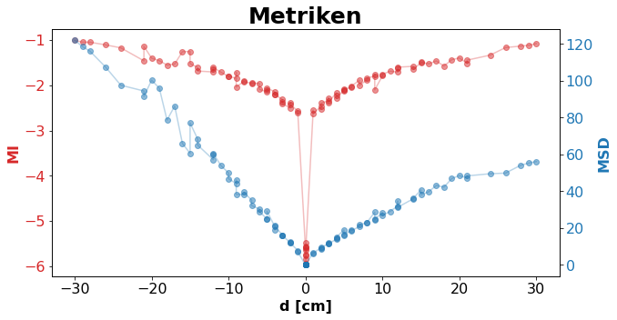

```python
fig, ax = plt.subplots(figsize=(10,5))

ax.set_xlabel('d [cm]')
ax.set_title('Metriken')
ax.scatter(dist, -MI, color='tab:red', alpha=0.5)
ax.plot(dist, -MI, color='tab:red', alpha=0.3)
ax.set_ylabel('MI', color='tab:red')
ax.tick_params(axis='y', labelcolor='tab:red')

ax2 = ax.twinx()
ax2.scatter(dist, MSD, color='tab:blue', alpha=0.5)
ax2.plot(dist, MSD, color='tab:blue', alpha=0.3)
ax2.set_ylabel('MSD', color='tab:blue')
ax2.tick_params(axis='y', labelcolor='tab:blue')
```

Die MI-Metrik zeigt ein deutliches schärferes Minimum.

# Aufgabe 2

## 2.1 Monomodal (CT $\rightarrow$ CT)

Es werden alle 6 Parameter um den idealen Parameterwert varriiert:

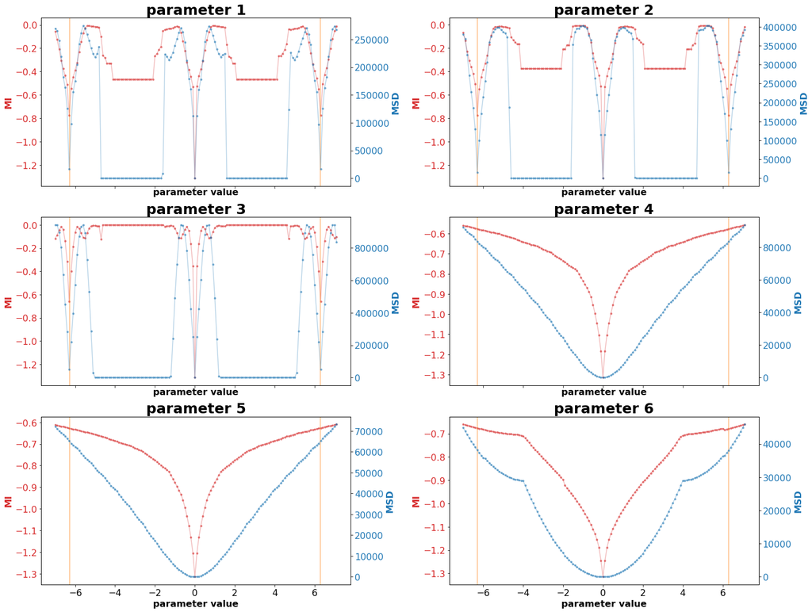

```python
parameters = [np.loadtxt(f'aufgabe2/mono/mono_parameter_{i+1}.txt').T for i in range(6)]

fig, axs = plt.subplots(3,2, tight_layout=True, figsize=(20,15), sharex=True)
axs = axs.reshape(-1)

for i in range(6):
    parameter = parameters[i]
    v = parameter[0]
    MI = parameter[1]
    MSD = parameter[2]

    ax = axs[i]
    ax.set_xlabel('parameter value')
    ax.set_title(f'parameter {i+1}')
    ax.scatter(v, MI, color='tab:red', alpha=0.5, s=8)
    ax.plot(v, MI, color='tab:red', alpha=0.3)
    ax.set_ylabel('MI', color='tab:red')
    ax.tick_params(axis='y', labelcolor='tab:red')

    ax.axvline(2*np.pi, color='tab:orange', alpha=0.5)
    ax.axvline(-2*np.pi, color='tab:orange', alpha=0.5)

    ax2 = ax.twinx()
    ax2.scatter(v, MSD, color='tab:blue', alpha=0.5, s=8)
    ax2.plot(v, MSD, color='tab:blue', alpha=0.3)
    ax2.set_ylabel('MSD', color='tab:blue')
    ax2.tick_params(axis='y', labelcolor='tab:blue')
```

Beide Methode finden das gleiche Optimum.

- Rotation: Parameter 1-3 (siehe $2\pi$-Periodizität [gelbe Linien])
- Translation: Parameter 4-6

Bei der MSD-Metrik ist anzumerken, dass es ein breites **falsches** lokales Minimum bei der Rotation gibt. Grund: Die Bilder überlappen sich nicht mehr (kaum). Dieses Plateu gibt es auch bei der MI-Metrik, allerdings ist dies kein totales Minimum.

## 2.2 Multimodal (CT $\rightarrow$ MRT)

Es wird jeweils ein Rotations- und ein Translationsparameter variiert.

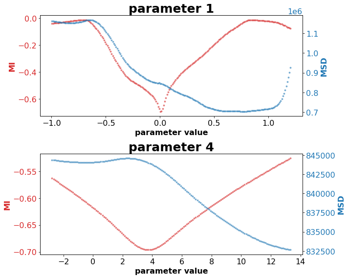

```python
parameters_multi = [np.loadtxt(f'aufgabe2/multi/multi_parameter_{i}.txt').T for i in [1,4]]

fig, axs = plt.subplots(2,1, tight_layout=True, figsize=(10,8))
for i, name in zip(range(2),['parameter 1', 'parameter 4']):
    parameter = parameters_multi[i]
    v = parameter[0]
    MI = parameter[1]
    MSD = parameter[2]

    ax = axs[i]
    ax.set_xlabel('parameter value')
    ax.set_title(name)
    ax.scatter(v, MI, color='tab:red', alpha=0.5, s=8)
    ax.set_ylabel('MI', color='tab:red')
    ax.tick_params(axis='y', labelcolor='tab:red')

    ax2 = ax.twinx()
    ax2.scatter(v, MSD, color='tab:blue', alpha=0.5, s=8)
    ax2.set_ylabel('MSD', color='tab:blue')
    ax2.tick_params(axis='y', labelcolor='tab:blue')
```

Die MSD-Metrik schlägt wie zu erwarten fehl.

## 2.3 Anzahl der Bins

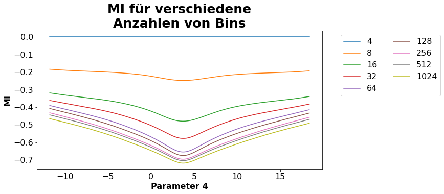

```python
nBins = [4, 8, 16, 32, 64, 128, 256, 512, 1024]
parameter_bins = [np.loadtxt(f'aufgabe2/multi/multi_nBins_{n}.txt').T for n in nBins]

plt.figure(figsize=(10,5))
plt.title('MI für verschiedene\nAnzahlen von Bins')
plt.xlabel('Parameter 4')
plt.ylabel('MI')
for i, n in zip(range(9), nBins):
    parameter = parameter_bins[i]
    v = parameter[0]
    MI = parameter[1]

    plt.plot(v, MI, label=n)
plt.legend(ncol=2, bbox_to_anchor=(1.05, 1), fontsize='16')
plt.show()
```

# Aufgabe 3

Zunächst werden gute Registrierungsparameter gesucht. Dabei wird die `samplingPercentage` konstant bei 0.4 belassen.

```python
explore_data = np.loadtxt('aufgabe3/parameterExploration.txt', skiprows=1)
columns = ['#levels', 'shrinking', 'smoothing', 'sampling', 'time [s]', 'cost', 'error [px]']
df = pd.DataFrame(explore_data, columns=columns)

def display_side_by_side(*args,titles=cycle([''])):
    html_str=''
    for df,title in zip(args, chain(titles,cycle(['</br>'])) ):
        html_str+='<th style="text-align:center"><td style="vertical-align:top">'
        html_str+=f'<h2>{title}</h2>'
        html_str+=df.to_html().replace('table','table style="display:inline"')
        html_str+='</td></th>'
    display_html(html_str,raw=True)

display_side_by_side(df[:24],df[24:], titles=['Überblick'])
```

Überblick

|  | #levels | shrinking | smoothing | sampling | time [s] | cost | error [px] |
| --- | --- | --- | --- | --- | --- | --- | --- |
| 0 | 2.0 | 1.0 | 0.0 | 0.4 | 71.91 | -0.51 | 18.50 |
| 1 | 2.0 | 1.5 | 0.0 | 0.4 | 87.12 | -0.53 | 11.57 |
| 2 | 2.0 | 2.0 | 0.0 | 0.4 | 13.29 | -0.51 | 21.25 |
| 3 | 2.0 | 2.5 | 0.0 | 0.4 | 8.79 | -0.51 | 22.97 |
| 4 | 2.0 | 1.0 | 1.0 | 0.4 | 111.86 | -0.55 | 21.26 |
| 5 | 2.0 | 1.5 | 1.0 | 0.4 | 112.06 | -0.59 | 9.56 |
| 6 | 2.0 | 2.0 | 1.0 | 0.4 | 11.26 | -0.55 | 20.91 |
| 7 | 2.0 | 2.5 | 1.0 | 0.4 | 10.06 | -0.55 | 19.46 |
| 8 | 2.0 | 1.0 | 2.0 | 0.4 | 162.63 | -0.75 | 1.19 |
| 9 | 2.0 | 1.5 | 2.0 | 0.4 | 116.51 | -0.70 | 3.92 |
| 10 | 2.0 | 2.0 | 2.0 | 0.4 | 16.80 | -0.77 | 1.19 |
| 11 | 2.0 | 2.5 | 2.0 | 0.4 | 28.95 | -0.77 | 1.16 |
| 12 | 2.0 | 1.0 | 4.0 | 0.4 | 297.54 | -0.70 | 44.89 |
| 13 | 2.0 | 1.5 | 4.0 | 0.4 | 193.83 | -0.83 | 2.22 |
| 14 | 2.0 | 2.0 | 4.0 | 0.4 | 17.34 | -0.84 | 1.83 |
| 15 | 2.0 | 2.5 | 4.0 | 0.4 | 14.93 | -0.72 | 41.46 |
| 16 | 3.0 | 1.0 | 0.0 | 0.4 | 140.74 | -0.51 | 21.94 |
| 17 | 3.0 | 1.5 | 0.0 | 0.4 | 116.87 | -0.51 | 17.74 |
| 18 | 3.0 | 2.0 | 0.0 | 0.4 | 27.37 | -0.53 | 13.37 |
| 19 | 3.0 | 2.5 | 0.0 | 0.4 | 16.09 | -0.53 | 13.03 |
| 20 | 3.0 | 1.0 | 1.0 | 0.4 | 265.36 | -0.56 | 18.34 |
| 21 | 3.0 | 1.5 | 1.0 | 0.4 | 154.76 | -0.60 | 8.22 |
| 22 | 3.0 | 2.0 | 1.0 | 0.4 | 17.20 | -0.56 | 22.10 |
| 23 | 3.0 | 2.5 | 1.0 | 0.4 | 27.58 | -0.57 | 23.25 |

|  | #levels | shrinking | smoothing | sampling | time [s] | cost | error [px] |
| --- | --- | --- | --- | --- | --- | --- | --- |
| 24 | 3.0 | 1.0 | 2.0 | 0.4 | 197.30 | -0.76 | 1.30 |
| 25 | 3.0 | 1.5 | 2.0 | 0.4 | 215.37 | -0.75 | 1.62 |
| 26 | 3.0 | 2.0 | 2.0 | 0.4 | 33.78 | -0.77 | 1.31 |
| 27 | 3.0 | 2.5 | 2.0 | 0.4 | 24.68 | -0.77 | 1.42 |
| 28 | 3.0 | 1.0 | 4.0 | 0.4 | 235.25 | -0.83 | 2.19 |
| 29 | 3.0 | 1.5 | 4.0 | 0.4 | 208.13 | -0.83 | 1.99 |
| 30 | 3.0 | 2.0 | 4.0 | 0.4 | 25.60 | -0.82 | 3.35 |
| 31 | 3.0 | 2.5 | 4.0 | 0.4 | 20.94 | -0.83 | 2.14 |
| 32 | 4.0 | 1.0 | 0.0 | 0.4 | 191.76 | -0.51 | 28.94 |
| 33 | 4.0 | 1.5 | 0.0 | 0.4 | 165.37 | -0.53 | 11.25 |
| 34 | 4.0 | 2.0 | 0.0 | 0.4 | 28.54 | -0.52 | 26.48 |
| 35 | 4.0 | 2.5 | 0.0 | 0.4 | 14.61 | -0.55 | 17.57 |
| 36 | 4.0 | 1.0 | 1.0 | 0.4 | 160.31 | -0.56 | 15.56 |
| 37 | 4.0 | 1.5 | 1.0 | 0.4 | 161.20 | -0.55 | 16.76 |
| 38 | 4.0 | 2.0 | 1.0 | 0.4 | 31.93 | -0.56 | 22.17 |
| 39 | 4.0 | 2.5 | 1.0 | 0.4 | 22.10 | -0.56 | 20.13 |
| 40 | 4.0 | 1.0 | 2.0 | 0.4 | 269.86 | -0.75 | 1.06 |
| 41 | 4.0 | 1.5 | 2.0 | 0.4 | 227.91 | -0.75 | 1.26 |
| 42 | 4.0 | 2.0 | 2.0 | 0.4 | 43.50 | -0.77 | 1.18 |
| 43 | 4.0 | 2.5 | 2.0 | 0.4 | 32.77 | -0.76 | 1.52 |
| 44 | 4.0 | 1.0 | 4.0 | 0.4 | 266.05 | -0.72 | 34.12 |
| 45 | 4.0 | 1.5 | 4.0 | 0.4 | 219.19 | -0.83 | 2.23 |
| 46 | 4.0 | 2.0 | 4.0 | 0.4 | 24.09 | -0.82 | 2.20 |
| 47 | 4.0 | 2.5 | 4.0 | 0.4 | 42.38 | -0.84 | 2.30 |

```python
df_by_cost = df.sort_values(by=['cost'])
df_by_error = df.sort_values(by=['error [px]'])

display_side_by_side(
    df_by_cost[:5],df_by_error[:5],
    titles=['Top5 (sortiert nach Metrik)', 'Top5 (sortiert nach Error)']
)
```

Top5 (sortiert nach Metrik)

|  | #levels | shrinking | smoothing | sampling | time [s] | cost | error [px] |
| --- | --- | --- | --- | --- | --- | --- | --- |
| 47 | 4.0 | 2.5 | 4.0 | 0.4 | 42.38 | -0.84 | 2.30 |
| 14 | 2.0 | 2.0 | 4.0 | 0.4 | 17.34 | -0.84 | 1.83 |
| 31 | 3.0 | 2.5 | 4.0 | 0.4 | 20.94 | -0.83 | 2.14 |
| 29 | 3.0 | 1.5 | 4.0 | 0.4 | 208.13 | -0.83 | 1.99 |
| 13 | 2.0 | 1.5 | 4.0 | 0.4 | 193.83 | -0.83 | 2.22 |

Top5 (sortiert nach Error)

|  | #levels | shrinking | smoothing | sampling | time [s] | cost | error [px] |
| --- | --- | --- | --- | --- | --- | --- | --- |
| 40 | 4.0 | 1.0 | 2.0 | 0.4 | 269.86 | -0.75 | 1.06 |
| 11 | 2.0 | 2.5 | 2.0 | 0.4 | 28.95 | -0.77 | 1.16 |
| 42 | 4.0 | 2.0 | 2.0 | 0.4 | 43.50 | -0.77 | 1.18 |
| 8 | 2.0 | 1.0 | 2.0 | 0.4 | 162.63 | -0.75 | 1.19 |
| 10 | 2.0 | 2.0 | 2.0 | 0.4 | 16.80 | -0.77 | 1.19 |

- #levels = 2
- shrinking-factor = 2.5
- smoothing-factor = 2.0

Als nächstes wird das Zeitverhalten und die Registrierungsgenauigkeit in Abhängigkeit der Stichprobengröße zur Berechnung der Metrik untersucht. Es wir die Stichprobengröße variiert, die restlichen Parameter werden nach Setup **11** gewählt.

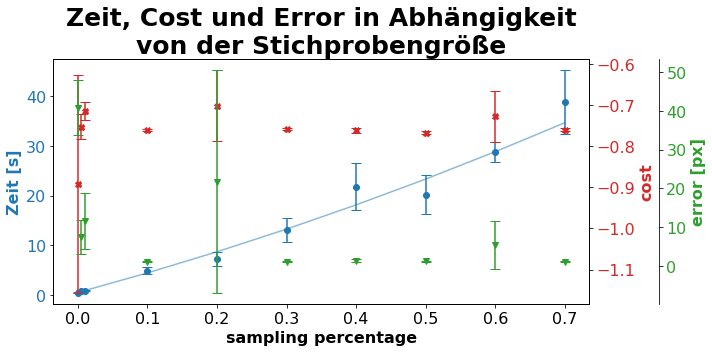

```python
sampling_data = np.loadtxt('aufgabe3/sampling_strategy.txt', skiprows=1)
perc = sampling_data[:,3]
time = sampling_data[:,4]
cost = sampling_data[:,5]
error = sampling_data[:,6]

data = [time, cost, error]
perc = np.array([np.mean(perc[i:i+3]) for i in range(0,30,3)])
time, cost, error = np.array([
    [
        [np.mean(arr[i:i+3]), np.std(arr[i:i+3])]
        for i in range(0,30,3)
    ]
    for arr in data
])

def parabel(x,a,b,c):
    return a*x**2 + b*x + c

popt, pcov = curve_fit(parabel, perc, time.T[0], sigma=time.T[1])
fig, ax = plt.subplots(figsize=(10,5),tight_layout=True)
ax.errorbar(perc, time.T[0], time.T[1], fmt='o', capsize=5, zorder=1)
ax.plot(perc, parabel(perc, *popt), color='tab:blue', alpha=0.5)
ax.set_xlabel('sampling percentage')
ax.set_ylabel('Zeit [s]', color='tab:blue')
ax.set_title('Zeit, Cost und Error in Abhängigkeit\nvon der Stichprobengröße')
ax.tick_params(axis='y', labelcolor='tab:blue')

ax2 = ax.twinx()
ax2.errorbar(perc, cost.T[0], cost.T[1], fmt='X', capsize=5, color='tab:red', zorder=0)
ax2.set_ylabel('cost', color='tab:red')
ax2.tick_params(axis='y', labelcolor='tab:red')

ax3 = ax.twinx()
ax3.errorbar(perc, error.T[0], error.T[1], fmt='v', capsize=5, color='tab:green', zorder=-1)
ax3.set_ylabel('error [px]', color='tab:green')
ax3.tick_params(axis='y', labelcolor='tab:green')
for loc, spine in ax3.spines.items():
    if loc == 'right':
        spine.set_position(('outward', 70))
```

Die Cost- und Error-Werte bleiben relativ konstant, schwanken aber stärker für kleine Stichprobengrößen. Wenn man möchte kann man eine quadratische Funktion für die Zeitabhängigkeit fitten. Insgesamt ist die Stichprobengrößen von **0.4** sinnvoll.

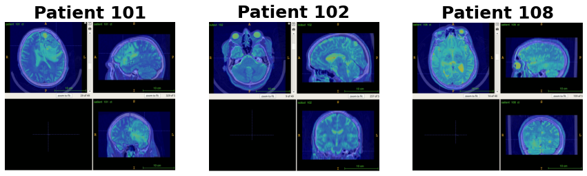

```python
ps = [101,102,108]
imgs = [plt.imread(f'aufgabe3/Patienten/{p}.png') for p in ps]
fig, axs = plt.subplots(1,3, figsize=(15,5))
for ax, img, p in zip(axs, imgs,ps):
    ax.imshow(img)
    ax.axis('off')
    ax.set_title(f'Patient {p}')
```

Um die Unterschiede in der Qualität zu zeigen werden die Registrierungen bei 2 schlechteren Parameterkonfigurationen dargestellt: Setup 12 und Setup 33

```python
display_side_by_side(
    df[12:13],df[33:34],
    titles=['sehr schlecht', 'mittel']
)
```

sehr schlecht

|  | #levels | shrinking | smoothing | sampling | time [s] | cost | error [px] |
| --- | --- | --- | --- | --- | --- | --- | --- |
| 12 | 2.0 | 1.0 | 4.0 | 0.4 | 297.54 | -0.7 | 44.89 |

mittel

|  | #levels | shrinking | smoothing | sampling | time [s] | cost | error [px] |
| --- | --- | --- | --- | --- | --- | --- | --- |
| 33 | 4.0 | 1.5 | 0.0 | 0.4 | 165.37 | -0.53 | 11.25 |

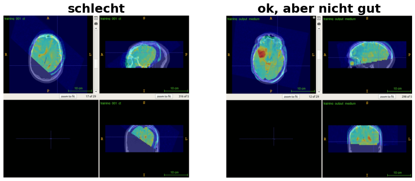

```python
ps = ["bad","medium"]
imgs = [plt.imread(f'aufgabe3/Patienten/101_{p}.png') for p in ps]
fig, axs = plt.subplots(1,2, figsize=(15,10))

titles = ['schlecht', 'ok, aber nicht gut']
for ax, img, t in zip(axs, imgs,titles):
    ax.imshow(img)
    ax.axis('off')
    ax.set_title(t)
```

# Aufgabe 4

In Aufgabe 4 geht es daum, ein Quadrat auf einen Kreis zu registrieren. Um besser zu veranschaulichen was passiert wird zusätlich noch ein Schachbrett mit transformiert.

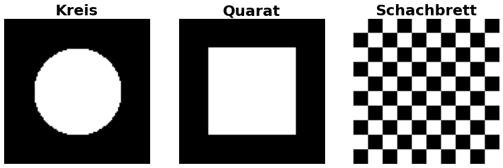

```python
names = ['fixed', 'moving', 'chessboard']
imgs = [plt.imread(f'aufgabe4/{n}.png') for n in names]

titles = ['Kreis', 'Quarat', 'Schachbrett']
fig, axs = plt.subplots(1,3, figsize=(15,5))
for ax, img, t in zip(axs, imgs,titles):
    ax.imshow(img, cmap='gray')
    ax.axis('off')
    ax.set_title(t)
```

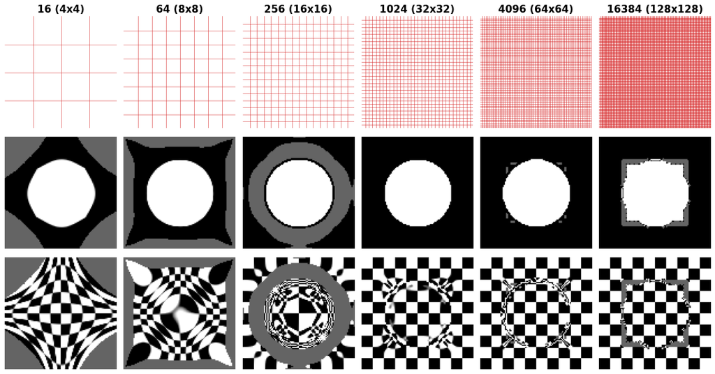

```python
n_grid = [4,8,16,32,64,128]
squares = [plt.imread(f'aufgabe4/square_{n}.png') for n in n_grid]
chessboards = [plt.imread(f'aufgabe4/chessboard_{n}.png') for n in n_grid]

fig, axs = plt.subplots(3,6,figsize=(15,8), sharex=True, sharey=True, tight_layout=True)
for ax, s, c, n in zip(axs.T, squares, chessboards, n_grid):
    lines = [100/n * i for i in range(1,n)]
    for l in lines:
        ax[0].axvline(l, linewidth=0.5, color='tab:red')
        ax[0].axhline(l, linewidth=0.5, color='tab:red')
    ax[0].set_aspect('equal', adjustable='box')

    ax[1].imshow(s, cmap='gray')
    ax[2].imshow(c, cmap='gray')

    ax[0].axis('off')
    ax[1].axis('off')
    ax[2].axis('off')

    ax[0].set_title(f'{n**2} ({n}x{n})', size=15)
```

Die grauen Bereiche sind undefiniert. Ab 64 Grids funktioniert die Registrierung gut, allerdings sind einige Bereiche undefiniert. Für 1024 Grids funktioniert die Registrierung perfekt. Für 64x64 werden einige Bereiche wieder undefiniert. Bei 128x128 Grids scheitert das Verfahren wieder. Vermutlich sind hier so viele Grids, das die Grids auf den Ecken des Quadrats nicht weit genug nach innen geschoben werden können.